# Figure 3

```r
library(piano)
library(fgsea)
library(ggplot2)

library(Matrix)
library(igraph)
library(data.table)
library(pheatmap)



gene_info <- fread("~/Code/tissue_biomarker/geneInfo.csv")

gene_info[, V1 := gsub(V1, pat = "\\.[0-9]+$", rep = "")]
```

```r
gene_symbol <- gene_info[, .(V1, gene_name)]

colnames(gene_symbol)[1] <- "Gene"
```

# 3a)

```r
metaRes <- fread("~/Code/tissue_biomarker/rnaResults/biomarker_res/mrna_gene_drug_tissue_res_pharmacodb.csv")

multiDrugTable <- metaRes[FWER_genes<0.05,.("Drugs" = paste(Drug, collapse = ", "), "N" = .N),.(Tissue, Gene)]
multiDrugTable <- metaRes[FWER_genes<0.05,.(Drug, "N" = .N),.(Tissue, Gene)]

multiDrugTable <- multiDrugTable[order(-N)]

metaRes2 <- data.frame(dcast(metaRes[Tissue == "Lung" & FWER_genes < 0.05], formula = Drug ~ Gene, value.var = "estimate", fill = 0))
rownames(metaRes2) <- metaRes2$Drug
metaRes2 <- data.matrix(metaRes2[, -1])

drugsMoreThan100 <- metaRes[FWER_genes < 0.05 & Tissue == "Lung", .N, Drug][N >= 100, Drug]

metaRes3 <- metaRes2[drugsMoreThan100, multiDrugTable[N > 3 & Tissue == "Lung", unique(Gene)]]


pdf("figures/zoom_on_lung_signal_heatmap.pdf", height = 4, width = 5)
pheatmap(metaRes3,
    clustering_distance_rows = "correlation", clustering_distance_cols = "correlation",
    clustering_method = "ward.D2", show_colnames = F, treeheight_col = 0
)
dev.off()
```

```r
pheatmap(metaRes3,
    clustering_distance_rows = "correlation", clustering_distance_cols = "correlation",
    clustering_method = "ward.D2", show_colnames = F, treeheight_col = 0
)
```

# 3b)

Lets look at a pathway analysis of these biomarkers. First, we identify the two clusters of drugs using simple hclust on a correlation distance.

```r
## Prepare reactome pathways and drug clusters

drugClust <- hclust(as.dist(1 - cor(t(metaRes3))), method = "ward.D2")

drugAssignment <- cutree(drugClust, k = 2)

reactomeBottom <- fread("~/Code/tissue_biomarker/pathways/ReactomeBottom.txt")
reactomeBottom <- reactomeBottom[V6=="Homo sapiens"]
reactomeBottom <- reactomeBottom[grepl(x=V1, pat="ENSG")]

reactomePaths <-  split(reactomeBottom$V1, reactomeBottom$V4)


## Prepare lists of genes signifying sensitivity to each cluster.

upInCluster1Sums <- colSums(sign(metaRes3[names(drugAssignment)[drugAssignment == 1], ]))

upInCluster1 <- colnames(metaRes3)[apply(metaRes3[names(drugAssignment)[drugAssignment == 1], ], 2, function(x) all(x >= 0) & any(x > 0))]
downInCluster1 <- colnames(metaRes3)[apply(metaRes3[names(drugAssignment)[drugAssignment == 1], ], 2, function(x) all(x <= 0) & any(x < 0))]

upInCluster2 <- colnames(metaRes3)[apply(metaRes3[names(drugAssignment)[drugAssignment == 2], ], 2, function(x) all(x >= 0) & any(x > 0))]
downInCluster2 <- colnames(metaRes3)[apply(metaRes3[names(drugAssignment)[drugAssignment == 2], ], 2, function(x) all(x <= 0) & any(x < 0))]

setdiff(union(upInCluster1, downInCluster2), intersect(upInCluster1, downInCluster2))
```

```
[1] "ENSG00000155189" "ENSG00000123136"
```

```
ENSG00000155189

ENSG00000123136
```

```r
setdiff(union(upInCluster2, downInCluster1), intersect(upInCluster2, downInCluster1))
```

```
[1] "ENSG00000188910" "ENSG00000089876" "ENSG00000006534" "ENSG00000089327"
[5] "ENSG00000115919" "ENSG00000164171"
```

```
ENSG00000188910

ENSG00000089876

ENSG00000006534

ENSG00000089327

ENSG00000115919

ENSG00000164171
```

```r
UpIn1Genes <- intersect(upInCluster1, downInCluster2)
UpIn2Genes <- intersect(upInCluster2, downInCluster1)


GeneAssignment <- data.frame(Gene = c(UpIn1Genes, UpIn2Genes), Cluster=c(rep(1,times=length(UpIn1Genes)),rep(2, times=length(UpIn2Genes))))

fwrite(GeneAssignment, file="LungClusteringGeneAssignment.csv")
```

## Go ORA Analysis

GO BP from mSigDB

```r
## For the msigdb sigs, we need to map to gene symbol.

UpIn1Genes <- gene_info[match((UpIn1Genes), V1), gene_name]
UpIn2Genes <- gene_info[match((UpIn2Genes), V1), gene_name]

upInCluster1 <- gene_info[match((upInCluster1), V1), gene_name]
upInCluster2 <- gene_info[match((upInCluster2), V1), gene_name]


downInCluster1 <- gene_info[match((downInCluster1), V1), gene_name]
downInCluster2 <- gene_info[match((downInCluster2), V1), gene_name]

## we also use all protein coding genes as the universe, as this is technically the filtering we did at the beginning of the biomarker analysis.

universe <- gene_info$gene_name[gene_info$gene_type == "protein_coding"]
```

```r
goBP <- fgsea::gmtPathways("~/Code/tissue_biomarker/pathways/c5.bp.v7.1.symbols.gmt")


goUp1 <- fgsea::fora(goBP, upInCluster1, universe = universe)
goDown1 <- fora(goBP, downInCluster1, universe=universe)
goUp2 <- fora(goBP, UpIn2Genes, universe = universe)
goDown2 <- fora(goBP, downInCluster2, universe=universe)
upIn1Genesets <- intersect(goUp1[padj<0.05, pathway],goDown2[padj<0.05, pathway])
downIn1Genesets <- intersect(goUp2[padj<0.05, pathway],goDown1[padj<0.05, pathway])

goUp1[,Phenotype:=1]
```

```r
goDown1[,Phenotype:=-1]
```

```r
cluster1Table <- rbind(goUp1[, .(pathway,pathway, pval, padj, Phenotype) ],
                        goDown1[, .(pathway,pathway, pval, padj, Phenotype) ])

colnames(cluster1Table) <- c("pathway", "Description", "p.Val", "FDR", "Phenotype")#, 'genes')


write.table(cluster1Table, file="lung_two_cluster_cluster1_enrichment.txt", sep="\t", row.names=F, quote=F)


goUp2[,Phenotype:=1]
```

```r
goDown2[,Phenotype:=-1]
```

```r
cluster2Table <- rbind(goUp2[, .(pathway,pathway, pval, padj, Phenotype) ],
                        goDown2[, .(pathway,pathway, pval, padj, Phenotype) ])

colnames(cluster2Table) <- c("pathway", "Description", "p.Val", "FDR", "Phenotype")#, 'genes')


write.table(cluster2Table, file="lung_two_cluster_cluster2_enrichment.txt", sep="\t", row.names=F, quote=F)


## Intersection of genes


goUp1 <- fgsea::fora(goBP, UpIn1Genes, universe = universe)
goDown1 <- fora(goBP, UpIn2Genes, universe = universe)
goUp1[, Phenotype := 1]
```

```r
goDown1[, Phenotype := -1]
```

```r
clusterTable <- rbind(
    goUp1[, .(pathway, pathway, pval, padj, Phenotype)],
    goDown1[, .(pathway, pathway, pval, padj, Phenotype)]
)


colnames(clusterTable) <- c("pathway", "Description", "p.Val", "FDR", "Phenotype") # , 'genes')


write.table(clusterTable, file = "lung_two_cluster_intersect_enrichment.txt", sep = "\t", row.names = F, quote = F)
```

There were many results here, so we write it out to take a look at it using enrichmentbrowser in cytoscape.

# 3c)

One idea could be that we are seeing differences according to cell type of origin. To take a look at this, we can use the cell type signatures from mSigDB, looking specifically at lung signatures to decrease multiple testing.

```r
## c8 cell type analysis

c8paths <- fgsea::gmtPathways("~/Code/tissue_biomarker/pathways/c8.all.v7.5.1.symbols.gmt.txt")

c8paths_lung <- c8paths[grep("TRAVAGLINI", names(c8paths), ignore.case = T)]

c8UpInCluster1 <- fora(c8paths_lung, UpIn1Genes, universe = universe)
c8DownInCluster1 <- fora(c8paths_lung, UpIn2Genes, universe = universe)
```

These results are interesting! First of all, the HDAC/BLC2/NAMPT cluster is enriched in sensitivity markers that overlap with markers of Neuroendocrine Cells. However, Neuroendocrine cell type is a common characteristic of the two largest subtypes of SCLC. Furthermore, Subtype 1 of SCLC (the ASCL1 subtype) is hypothesized to be more sensitive to BCL2 and HDAC inhibitors, with clinical trials ongoing for BCL2. (BCL2 results previously reported by Lochmann et al., 2018).

Lets plot these enrichments:

```r
library(ggrepel)
toPlot <- c8UpInCluster1
toPlot[,pfer:=p.adjust(pval, method="bonferroni")]
```

```r
pdf("figures/c8UpIn1.pdf", width = 5, height = 7)
ggplot(toPlot, aes(overlap / size, -log10(pval))) +
    geom_point() +
    xlab("Percent Overlap between Markers") +
    ylab("-log10(Fisher Test p-Value)") +
    geom_hline(yintercept = -log10(0.05 / nrow(c8UpInCluster1))) +
    theme_bw() +
    geom_text_repel(data = toPlot[pfer < 0.05], aes(label = pathway), show.legend = F, max.overlaps = 5)
```

```r
dev.off()
```

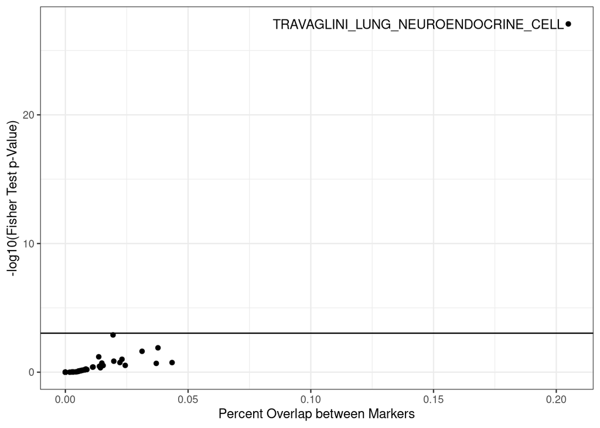

```r
ggplot(toPlot, aes(overlap / size, -log10(pval))) +
    geom_point() +
    xlab("Percent Overlap between Markers") +
    ylab("-log10(Fisher Test p-Value)") +
    geom_hline(yintercept = -log10(0.05 / nrow(c8UpInCluster1))) +
    theme_bw() +
    geom_text_repel(data = toPlot[pfer < 0.05], aes(label = pathway), show.legend = F, max.overlaps = 5)
```

# Supplementary Figure 4

```r
toPlot <- c8DownInCluster1
toPlot[, pfer := p.adjust(pval, method = "bonferroni")]
```

```r
pdf("figures/c8DownIn1.pdf", width = 7, height = 7)
ggplot(toPlot, aes(overlap / size, -log10(pval))) +
    geom_point() +
    xlab("Percent Overlap between Markers") +
    ylab("-log10(Fisher Test p-Value)") +
    geom_hline(yintercept = -log10(0.05 / nrow(toPlot))) +
    theme_bw() +
    geom_text_repel(data = toPlot[pfer < 0.05], aes(label = pathway), show.legend = F, max.overlaps = 5)
dev.off()
```

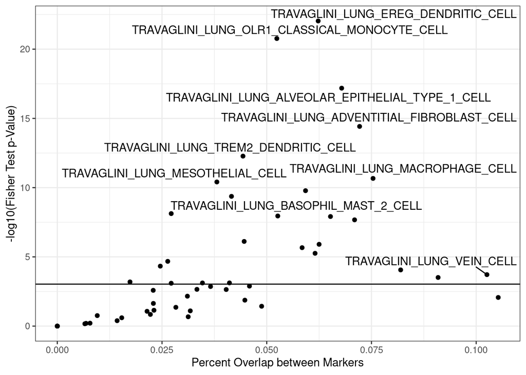

```r
ggplot(toPlot, aes(overlap / size, -log10(pval))) +
    geom_point() +
    xlab("Percent Overlap between Markers") +
    ylab("-log10(Fisher Test p-Value)") +
    geom_hline(yintercept = -log10(0.05 / nrow(toPlot))) +
    theme_bw() +
    geom_text_repel(data = toPlot[pfer < 0.05], aes(label = pathway), show.legend = F, max.overlaps = 5)
```

# 3d)

## Investigating signatures of particular SCLC subtypes

SCLC seems to be driven/subtyped by 4 main transcription factors: ASCL1, NEUROD1, YAP1, POU2F3. Using GTRD, I found genesets for targets of these transcription factors.

Additionally, MYCL1, BCL2, SOX2, DLL3 and CREBBP seem associated with the ASCL1 subtype, while MYC, HES6, HES1 and repression of ASCL1 are associated with NEUROD1. INSM1 seems to be associated with both.

Lets take a look at whether these genes appear individually first.

```r
library(pheatmap)

metaRes4 <- metaRes2[drugsMoreThan100, ]


colnames(metaRes4) <- gene_info[match(colnames(metaRes4), V1), gene_name]
genesOfInterest <- c("MYCL1", "BCL2", "SOX2", "DLL3", "CREBBP", "MYC", "INSM1", "HES1", "HES6", "ASCL1", "NEUROD1", "YAP1", "POU2F3")

metaRes4[c(names(drugAssignment[drugAssignment==1]),names(drugAssignment[drugAssignment==2])),intersect(colnames(metaRes4), c("MYCL1", "BCL2", "SOX2", "DLL3", "CREBBP", "MYC", "INSM1", "HES1", "HES6", "ASCL1", "NEUROD1", "YAP1", "POU2F3"))]
```

```
                   DLL3       HES1       YAP1      ASCL1       BCL2      INSM1
Panobinostat  0.0000000  0.0000000 -0.4253346  0.0000000  0.0000000  0.4365516
Daporinad     0.0000000 -0.4938955 -0.4511979  0.0000000  0.0000000  0.4605788
Navitoclax    0.4672077  0.0000000 -0.4691996  0.4383412  0.5413153  0.5575512
Vorinostat    0.0000000 -0.3621059 -0.4240104  0.0000000  0.0000000  0.4473255
PD-0325901    0.0000000  0.0000000  0.3951079  0.0000000  0.0000000 -0.4391500
Selumetinib   0.0000000  0.0000000  0.3287531  0.0000000  0.0000000 -0.3578039
Dasatinib     0.0000000  0.0000000  0.4683791  0.0000000  0.0000000 -0.4249613
Trametinib   -0.5061498  0.5270213  0.5099121 -0.4401398 -0.4770374 -0.6117539
```

```r
metaRes5 <- metaRes4
metaRes5[metaRes5==0] <- NA_real_
toPlot <- data.frame(t(metaRes5[c(names(drugAssignment[drugAssignment == 1]), names(drugAssignment[drugAssignment == 2])), ]))[genesOfInterest, ]


rownames(toPlot) <- genesOfInterest

pdf("figures/sclcmarkers.pdf", width = 6, height = 5)
pheatmap(toPlot,
    cluster_rows = F, cluster_cols = F

)
dev.off()
```

```r
pheatmap(toPlot,
    cluster_rows = F, cluster_cols = F
)
```

# Supplmentary Figures 5 and 6

```r
library(PharmacoGx)
library(ggplot2)
library(data.table)
library(reshape2)
drugsOfInterest <- c("Daporinad", "Selumetinib", "Trametinib", "PD-0325901", "Vorinostat", "Navitoclax", "Dasatinib", "Panobinostat")


gene.info <- read.csv("~/Code/tissue_biomarker/geneInfo.csv")

GDSC1 <- updateObject(readRDS("~/Data/TBPInputs/archive_2022_04_08/rna/GDSC1.rds"))
GDSC2 <- updateObject(readRDS("~/Data/TBPInputs/archive_2022_04_08/rna/GDSC2.rds"))
CCLE <- updateObject(readRDS("~/Data/TBPInputs/archive_2022_04_08/rna/CCLE.rds"))
CTRPv2 <- updateObject(readRDS("~/Data/TBPInputs/archive_2022_04_08/rna/CCLE.CTRPv2.rds"))
gCSI <- updateObject(readRDS("~/Data/TBPInputs/archive_2022_04_08/rna/gCSI.rds"))

pset.list <- list(
    GDSC1,
    GDSC2,
    CCLE,
    gCSI,
    CTRPv2
)
```

```r
toPlotList <- lapply(pset.list, \(pset) {
    lungCells <- cellNames(pset)[cellInfo(pset)$tissueid == "Lung"]

    SCLC.diseases <- c("Small cell lung carcinoma", "Lung carcinoid tumor")
    NSCLC.diseases <- c(
        "Adenosquamous lung carcinoma", "Large cell lung carcinoma", "Lung adenocarcinoma", "Lung giant cell carcinoma",
        "Minimally invasive lung adenocarcinoma",
        "Non-small cell lung carcinoma", "Papillary lung adenocarcinoma", "Squamous cell lung carcinoma"
    )

    lungCancerType <- rep(NA_character_, length(lungCells))

    lungCancerType <- ifelse(cellInfo(pset)[lungCells, "Cellosaurus.Disease.Type"] %in% SCLC.diseases, "SCLC", lungCancerType)
    lungCancerType <- ifelse(cellInfo(pset)[lungCells, "Cellosaurus.Disease.Type"] %in% NSCLC.diseases, "NSCLC", lungCancerType)

    lungCancerType.m <- data.frame(Cell = lungCells, Disease = lungCancerType)
    aac.mat <- summarizeSensitivityProfiles(pset,
        sensitivity.measure = "aac_recomputed",
        drugs = drugsOfInterest,
        cell = lungCells,
        fill.missing = T
    )
    aac.mat.m <- melt(t(scale(t(aac.mat))))
    colnames(aac.mat.m) <- c("Drug", "Cell", "AAC")

    gene.exp <- summarizeMolecularProfiles(pset, mDataNames(pset))

    if (metadata(gene.exp)$annotation == "rna") {
        YAP1.ensg <- gsub(pat = "\\.[0-9]+$", rep = "", gene.info$gene_id[match("YAP1", gene.info$gene_name)])
        INSM1.ensg <- gsub(pat = "\\.[0-9]+$", rep = "", gene.info$gene_id[match("INSM1", gene.info$gene_name)])
    } else {
        YAP1.ensg <- gene.info$gene_id[match("YAP1", gene.info$gene_name)]
        INSM1.ensg <- gene.info$gene_id[match("INSM1", gene.info$gene_name)]
    }

    YAP1.exp.mat.m <- melt(assay(gene.exp[YAP1.ensg, lungCells]))[, -1]
    INSM1.exp.mat.m <- melt(assay(gene.exp[INSM1.ensg, lungCells]))[, -1]
    colnames(YAP1.exp.mat.m) <- c("Cell", "YAP1")
    colnames(INSM1.exp.mat.m) <- c("Cell", "INSM1")

    res <- merge(merge(merge(aac.mat.m, YAP1.exp.mat.m, by = "Cell"), INSM1.exp.mat.m, by = "Cell"), lungCancerType.m, by = "Cell")
    res$Dataset <- name(pset)
    return(res)
})
```

```
Summarizing rna molecular data for: GDSC_v1
```

```
Summarizing rna molecular data for: GDSC_v2
```

```
Summarizing rna molecular data for: CCLE
```

```
Summarizing Kallisto_0.46.1.rnaseq molecular data for:  gCSI
```

```r
toPlot <- rbindlist(toPlotList)

toPlot$Drug <- factor(toPlot$Drug, levels = c("Dasatinib", "Selumetinib", "Trametinib", "PD-0325901", "Vorinostat", "Navitoclax", "Daporinad", "Panobinostat"))


pdf("figures/lung_yap1_vs_aac.pdf", width = 8)
ggplot(toPlot[Dataset %in% c("CCLE.CTRPv2", "GDSC_v1", "GDSC_v2")], aes(x = YAP1, y = AAC, color = Disease)) +
    geom_point() +
    facet_grid(Drug ~ Dataset) +
    theme_bw() + ylab("z score (AAC)")
dev.off()
```

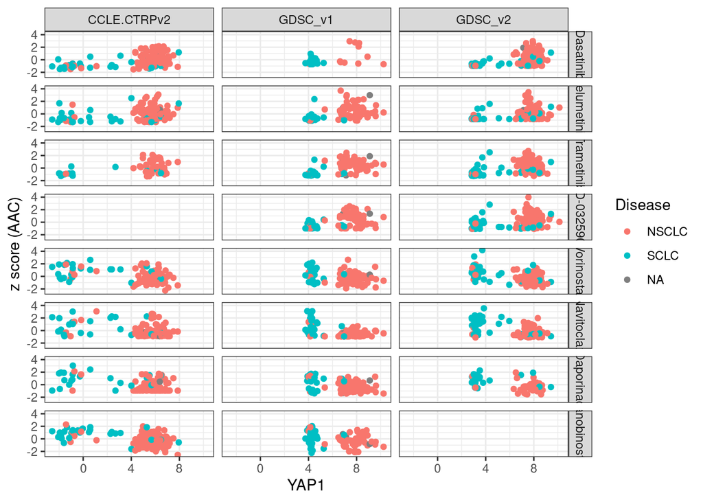

```r
ggplot(toPlot[Dataset %in% c("CCLE.CTRPv2", "GDSC_v1", "GDSC_v2")], aes(x = YAP1, y = AAC, color = Disease)) +
    geom_point() +
    facet_grid(Drug ~ Dataset) +
    theme_bw() + ylab("z score (AAC)")
```

```r
pdf("figures/lung_insm1_vs_aac.pdf", width=8)
ggplot(toPlot[Dataset %in% c("CCLE.CTRPv2", "GDSC_v1", "GDSC_v2")], aes(x = INSM1, y = AAC, color = Disease)) +
    geom_point() +
    facet_grid(Drug ~ Dataset) +
    theme_bw() +
    ylab("z score (AAC)")
dev.off()
```

[figure not shown]

```r
ggplot(toPlot[Dataset %in% c("CCLE.CTRPv2", "GDSC_v1", "GDSC_v2")], aes(x = YAP1, y = AAC, color = Disease)) +
    geom_point() +
    facet_grid(Drug ~ Dataset) +
    theme_bw() +
    ylab("z score (AAC)")
```

# 3e)

Lets classify cells based on YAP1 and INSM1 bimodality, and then see which is more predictive, disease label or expression.

```r
library(PRROC)
source("code/getBiModalScore.R")


yap1.by.dataset <- split(unique(toPlot[,.(Dataset, Cell, YAP1)]), by='Dataset')

yap1.by.dataset <- lapply(yap1.by.dataset, \(x) return(x[complete.cases(x)]))

yap1.bimodal.fit.by.dataset <- lapply(yap1.by.dataset, \(x) getBiModalScore_Updated(x[, YAP1], type = "gaussianMix"))
class.pred.by.dataset <- lapply(names(yap1.bimodal.fit.by.dataset), \(dataset){

    class1logp <- dnorm(yap1.by.dataset[[dataset]][[3]],
        mean = yap1.bimodal.fit.by.dataset[[dataset]]$mix$m.step$mu[[1]],
        sd = sqrt(yap1.bimodal.fit.by.dataset[[dataset]]$mix$m.step$var[[1]]), log = TRUE
    )
    class2logp <- dnorm(yap1.by.dataset[[dataset]][[3]],
        mean = yap1.bimodal.fit.by.dataset[[dataset]]$mix$m.step$mu[[2]],
        sd = sqrt(yap1.bimodal.fit.by.dataset[[dataset]]$mix$m.step$var[[2]]), log = TRUE
    )

    data.frame(Cell = yap1.by.dataset[[dataset]][[2]], Class=apply(cbind(class1logp, class2logp), 1, which.max))
})

names(class.pred.by.dataset) <- names(yap1.bimodal.fit.by.dataset)

class.pred.yap1 <- rbindlist(class.pred.by.dataset, idcol="Dataset")

yap1.merged = merge(toPlot, class.pred.yap1)
yap1.merged <- yap1.merged[complete.cases(yap1.merged)]

toPlot2 <- rbind(yap1.merged[, .(Predictor="Disease",AUROC= roc.curve(scores.class0 = AAC, weights.class0 = (Disease == "NSCLC"))[[2]]), .(Dataset, Drug)],
yap1.merged[, .(Predictor="Expression",AUROC=roc.curve(scores.class0 = AAC, weights.class0 = (Class == 2))[[2]]), .(Dataset, Drug)])

## Fixing the sign on the direction of prediction for drugs in the difference class

toPlot2[Drug %in% c("Vorinostat", "Navitoclax", "Daporinad", 'Panobinostat'), AUROC := 1-AUROC]
```

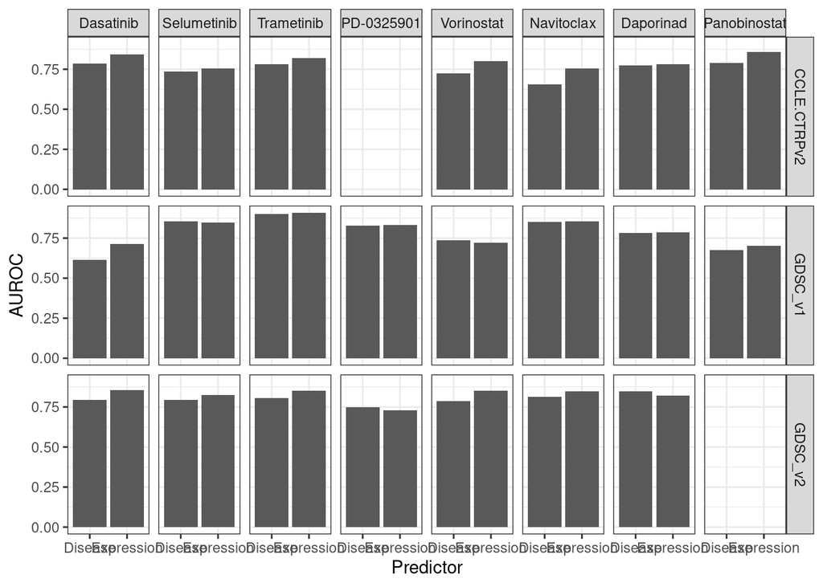

```r
toPlot2 <- toPlot2[Dataset %in% c("CCLE.CTRPv2", "GDSC_v1", "GDSC_v2")]

ggplot(toPlot2, aes(x = Predictor, y = AUROC)) +
    geom_col() +
    facet_grid(Dataset ~ Drug) +
    theme_bw()
```

```r
pdf("figures/lung_yap1_vs_disease_AUROCs.pdf", width = 8)
ggplot(toPlot2, aes(x = Predictor, y = AUROC)) +
    geom_col() +
    facet_grid(Dataset ~ Drug) + theme_bw() + theme(axis.text.x = element_text(angle=45, hjust=1))
```

```r
dev.off()
```

```r
toPlot2[,.SD[Predictor=="Expression",AUROC]>.SD[Predictor=="Disease",AUROC],.(Dataset, Drug)]
```

| Dataset | Drug | V1 |
| --- | --- | --- |
| GDSC_v2 | Selumetinib | TRUE |
| GDSC_v2 | Trametinib | TRUE |
| GDSC_v2 | PD-0325901 | FALSE |
| GDSC_v2 | Vorinostat | TRUE |
| GDSC_v2 | Navitoclax | TRUE |
| GDSC_v2 | Dasatinib | TRUE |
| GDSC_v1 | Daporinad | TRUE |
| GDSC_v1 | Selumetinib | FALSE |
| GDSC_v1 | Trametinib | TRUE |
| GDSC_v1 | PD-0325901 | TRUE |

[output cut: 12 more lines]

```r
pdf("figures/lung_yap1_vs_disease_AUROCs_boxplot.pdf", width = 5, height = 5)
boxplot(list(
    "YAP1 Expression" = toPlot2[Predictor == "Expression", AUROC],
    "Disease" = toPlot2[Predictor == "Disease", AUROC]
), ylab = "AUROC")
dev.off()
```

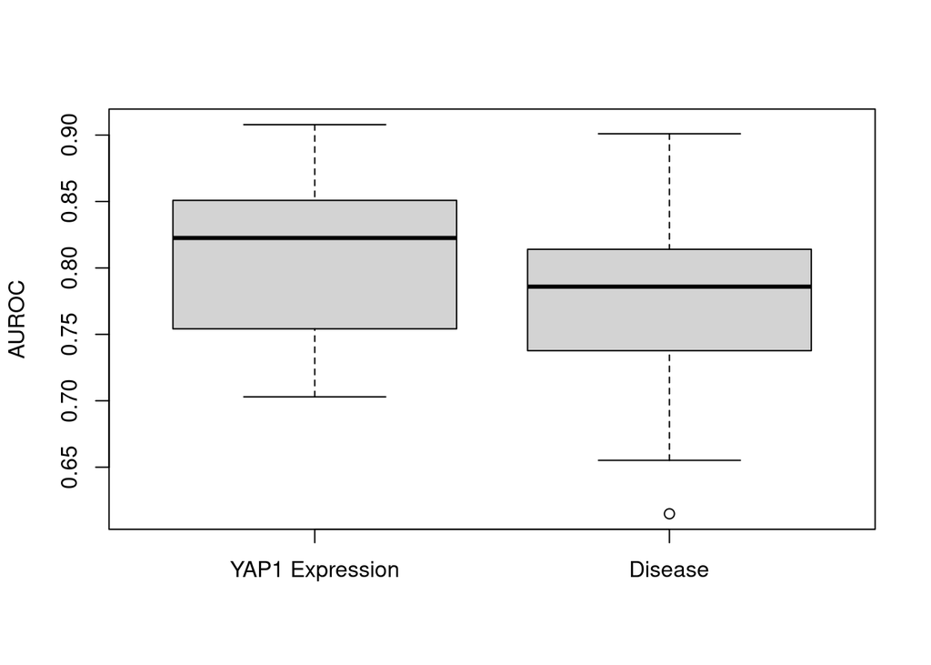

```r
boxplot(list(
    "YAP1 Expression" = toPlot2[Predictor == "Expression", AUROC],
    "Disease" = toPlot2[Predictor == "Disease", AUROC]), ylab = "AUROC"
)
```

```r
insm1.by.dataset <- split(unique(toPlot[, .(Dataset, Cell, INSM1)]), by = "Dataset")

insm1.by.dataset <- lapply(insm1.by.dataset, \(x) return(x[complete.cases(x)]))

insm1.bimodal.fit.by.dataset <- lapply(insm1.by.dataset, \(x) getBiModalScore_Updated(x[, INSM1], type = "gaussianMix"))

class.pred.by.dataset <- lapply(names(insm1.bimodal.fit.by.dataset), \(dataset){
    class1logp <- dnorm(insm1.by.dataset[[dataset]][[3]],
        mean = insm1.bimodal.fit.by.dataset[[dataset]]$mix$m.step$mu[[1]],
        sd = sqrt(insm1.bimodal.fit.by.dataset[[dataset]]$mix$m.step$var[[1]]), log = TRUE
    )
    class2logp <- dnorm(insm1.by.dataset[[dataset]][[3]],
        mean = insm1.bimodal.fit.by.dataset[[dataset]]$mix$m.step$mu[[2]],
        sd = sqrt(insm1.bimodal.fit.by.dataset[[dataset]]$mix$m.step$var[[2]]), log = TRUE
    )

    data.frame(Cell = insm1.by.dataset[[dataset]][[2]], Class = apply(cbind(class1logp, class2logp), 1, which.max))
})

names(class.pred.by.dataset) <- names(insm1.bimodal.fit.by.dataset)

class.pred.insm1 <- rbindlist(class.pred.by.dataset, idcol = "Dataset")

insm1.merged <- merge(toPlot, class.pred.insm1)
insm1.merged <- insm1.merged[complete.cases(insm1.merged)]

toPlot3 <- rbind(
    insm1.merged[, .(Predictor = "Disease", AUROC = roc.curve(scores.class0 = AAC, weights.class0 = (Disease == "NSCLC"))[[2]]), .(Dataset, Drug)],
    insm1.merged[, .(Predictor = "Expression", AUROC = roc.curve(scores.class0 = AAC, weights.class0 = (Class == 1))[[2]]), .(Dataset, Drug)]
)

## Fixing the sign on the direction of prediction for drugs in the difference class

toPlot3[Drug %in% c("Vorinostat", "Navitoclax", "Daporinad", "Panobinostat"), AUROC := 1 - AUROC]
```

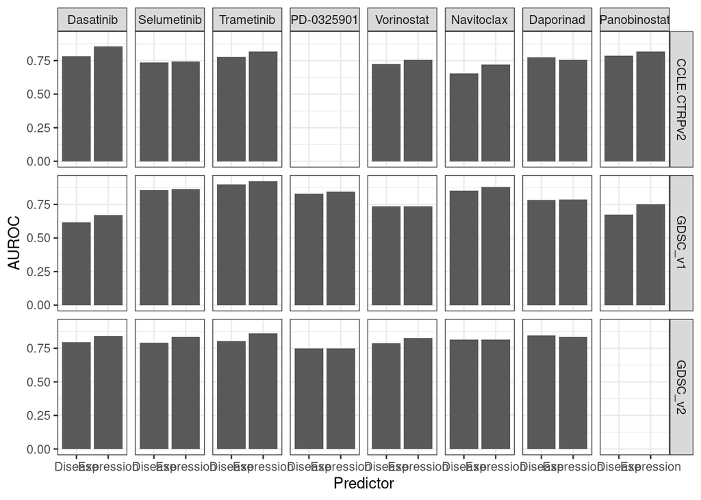

```r
toPlot3 <- toPlot3[Dataset %in% c("CCLE.CTRPv2", "GDSC_v1", "GDSC_v2")]


ggplot(toPlot3[Dataset %in% c("CCLE.CTRPv2", "GDSC_v1", "GDSC_v2")], aes(x = Predictor, y = AUROC)) +
    geom_col() +
    facet_grid(Dataset ~ Drug) + theme_bw()
```

```r
pdf("figures/lung_insm1_vs_disease_AUROCs.pdf", width = 8)

ggplot(toPlot3[Dataset %in% c("CCLE.CTRPv2", "GDSC_v1", "GDSC_v2")], aes(x = Predictor, y = AUROC)) +
    geom_col() +
    facet_grid(Dataset ~ Drug) + theme_bw() + theme(axis.text.x = element_text(angle = 45, hjust = 1))
```

```r
dev.off()
```

```r
toPlot3[, .SD[Predictor == "Expression", AUROC] > .SD[Predictor == "Disease", AUROC], .(Dataset, Drug)]
```

| Dataset | Drug | V1 |
| --- | --- | --- |
| GDSC_v2 | Selumetinib | TRUE |
| GDSC_v2 | Trametinib | TRUE |
| GDSC_v2 | PD-0325901 | FALSE |
| GDSC_v2 | Vorinostat | TRUE |
| GDSC_v2 | Navitoclax | TRUE |
| GDSC_v2 | Dasatinib | TRUE |
| GDSC_v1 | Daporinad | TRUE |
| GDSC_v1 | Selumetinib | TRUE |
| GDSC_v1 | Trametinib | TRUE |
| GDSC_v1 | PD-0325901 | TRUE |

[output cut: 12 more lines]

```r
pdf("figures/lung_insm1_vs_disease_AUROCs_boxplot.pdf", width = 5, height=5)
boxplot(list("INSM1 Expression"=toPlot3[Predictor == "Expression", AUROC],
         "Disease"=toPlot3[Predictor == "Disease", AUROC]), ylab="AUROC")
dev.off()
```

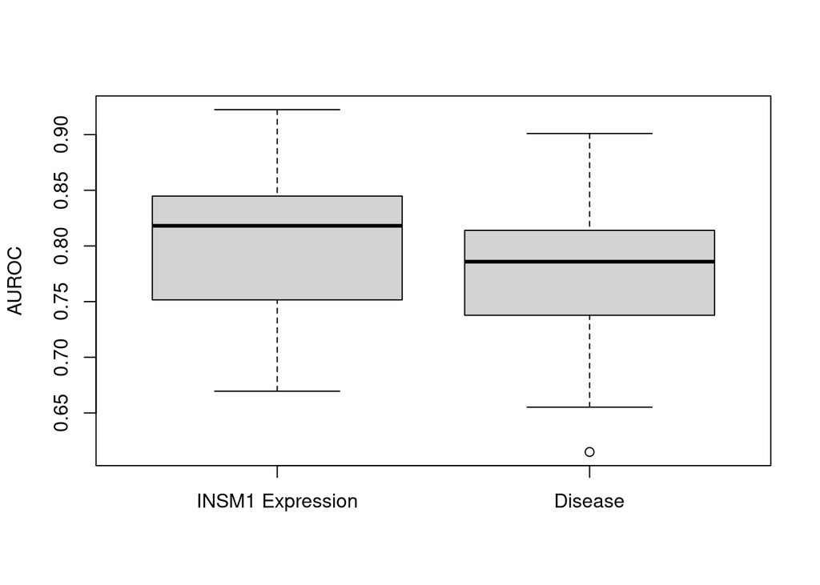

```r
boxplot(list(
    "INSM1 Expression" = toPlot3[Predictor == "Expression", AUROC],
    "Disease" = toPlot3[Predictor == "Disease", AUROC]), ylab="AUROC"
)
```